# McNally et al. Larval Biomineralization

```r
coefvariation<- function(x){
  sd(x,na.rm=T)/abs(mean(x, na.rm=T))
}

logitTransform<- function(p){
  log(p/(1-p))
}
```

```r
CarbChemTable<- as.data.frame(matrix(nrow=50, ncol=4)) # make a table to hold the carbonate summary data. This table will be for just 2 pCO2 levels: Control & OA
colnames(CarbChemTable)<- paste(c("Parameter", "Statistic", "Control", "OA"))
CarbChemTable$Parameter<- c("CALCULATED PARAMETERS", "pCO2(gas-e)", rep("", times=3), "TA",rep("", times=3),"[CO32-]",rep("", times=3), "[HCO3-]", rep("", times=3), "[CO2](aq)", rep("", times=3), "SatCalcite", rep("", times=3), "SatAragonite", rep("", times=3),"MEASURED PARAMETERS", "salinity", rep("", times=3), "Temperature", rep("", times=3),"pH", rep("", times=3), "DIC", rep("", times=3), "TA", rep("", times=3))
CarbChemTable$Statistic<- paste(c("", "(ppm-v)", "SD", "Range", "n",
"(uM)", "SD", "Range", "n",
"(uM)", "SD", "Range", "n",
"(uM)", "SD", "Range", "n",
"(uM)", "SD", "Range", "n",
"", "SD", "Range", "n",
"", "SD", "Range", "n", "",
"(ppt)", "SD", "Range", "n",
"(C)", "SD", "Range", "n",
"(Total)", "SD", "Range", "n",
"(uM)", "SD", "Range", "n",
"(uM)", "SD", "Range", "n")) #note you will have to change the pH scale if you aren't using the total scale
#now that table has been made, we can fill it in with the values using the CarbChemSummary function

#name the column rows the following:
# Trt - treatment
# pH
# Sal - salinity
# Temp - temperature
# DIC
# ATmeas - AT measured
# ATcalc - AT calculated
# pCO2
# HCO3
# CO3
# CO2
# Calcite - calcite saturation state
# Aragonite - aragonite saturation state

CarbChemSummary<- function(DF){
  Data<- subset(DF, select= c("Trt", "pH", "Sal", "Temp", "DIC", "ATmeas", "ATcalc", "pCO2", "HCO3", "CO3", "CO2", "Calcite", "Aragonite")) #select only the relevant fields
  Means<- ddply(Data, .(Trt), numcolwise(mean, na.rm=T)) #get the means
  Means[,2]<- round(Means[,2], 2) #round pH to 2 decimal places
  Means[,3:4]<- round(Means[,3:4], 1) #round salinity & temperature to one decimal place
  Means[,12:13]<- round(Means[,12:13],3) #round calcite & aragonite sat to 3 decimal places
  Means[,5:11]<-round(Means[,5:11]) # round AT, DIC, pCO2, CO3, CO2, and HCO3 to no decimal places.

  SDs<- ddply(Data, .(Trt), numcolwise(sd, na.rm=T))
  SDs[,2]<- round(SDs[,2], 2) #round pH to 2 decimal places
  SDs[,3:4]<- round(SDs[,3:4], 1) #round salinity & temperature to one decimal place
  SDs[,12:13]<- round(SDs[,12:13], 3) #round calcite & aragonite sat to 3 decimal places
  SDs[,5:11]<-round(SDs[,5:11]) # round AT, DIC, pCO2, CO3, CO2, and HCO3 to no decimal places.

  Mins<- ddply(Data, .(Trt), numcolwise(min, na.rm=T))
  Mins[,2]<- round(Mins[,2], 2) #round pH to 2 decimal places
  Mins[,3:4]<- round(Mins[,3:4], 1) #round salinity & temperature to one decimal place
  Mins[,12:13]<- round(Mins[,12:13], 3) #round calcite & aragonite sat to 3 decimal places
  Mins[,5:11]<-round(Mins[,5:11]) # round AT, DIC, pCO2, CO3, CO2, and HCO3 to no decimal places.

  Maxs<- ddply(Data, .(Trt), numcolwise(max, na.rm=T))
  Maxs[,2]<- round(Maxs[,2], 2) #round pH to 2 decimal places
  Maxs[,3:4]<- round(Maxs[,3:4], 1) #round salinity & temperature to one decimal place
  Maxs[,12:13]<- round(Maxs[,12:13], 3) #round calcite & aragonite sat to 3 decimal places
  Maxs[,5:11]<-round(Maxs[,5:11]) # round AT, DIC, pCO2, CO3, CO2, and HCO3 to no decimal places.

  RangesControl<- paste(Mins[1,2:13], Maxs[1,2:13], sep="-")
  RangesExp<- paste(Mins[2,2:13], Maxs[2,2:13], sep="-") #note, you will  need to add more if you have >2 treatments
  Counts<- ddply(Data, .(Trt), numcolwise(length))
  #put all of the data into the summary table
  CarbChemTable[,3]<-paste(c("", Means[1,8], SDs[1,8], RangesControl[7], Counts[1,8], Means[1,7], SDs[1,7], RangesControl[6], Counts[1,7], Means[1,10], SDs[1,10], RangesControl[9], Counts[1,10], Means[1,9], SDs[1,9], RangesControl[8], Counts[1,9],Means[1,11], SDs[1,11], RangesControl[10], Counts[1,11], Means[1,12], SDs[1,12], RangesControl[11], Counts[1,12],Means[1,13], SDs[1,13], RangesControl[12], Counts[1,13], "", Means[1,3], SDs[1,3], RangesControl[2], Counts[1,3], Means[1,4], SDs[1,4], RangesControl[3], Counts[1,4],Means[1,2], SDs[1,2], RangesControl[1], Counts[1,2], Means[1,5], SDs[1,5], RangesControl[4], Counts[1,5], Means[1,6], SDs[1,6], RangesControl[5], Counts[1,6]))
    CarbChemTable[,4]<-paste(c("", Means[2,8], SDs[2,8], RangesExp[7], Counts[2,8], Means[2,7], SDs[2,7], RangesExp[6], Counts[2,7], Means[2,10], SDs[2,10], RangesExp[9], Counts[2,10], Means[2,9], SDs[2,9], RangesExp[8], Counts[2,9],Means[2,11], SDs[2,11], RangesExp[10], Counts[2,11], Means[2,12], SDs[2,12], RangesExp[11], Counts[2,12],Means[2,13], SDs[2,13], RangesExp[12], Counts[2,13], "", Means[2,3], SDs[2,3], RangesExp[2], Counts[2,3], Means[2,4], SDs[2,4], RangesExp[3], Counts[2,4],Means[2,2], SDs[2,2], RangesExp[1], Counts[2,2], Means[2,5], SDs[2,5], RangesExp[4], Counts[2,5], Means[2,6], SDs[2,6], RangesExp[5], Counts[2,6]))
    CarbChemTable
}
```

## Load data

Name the data you export from FileMaker Pro by their exact table names and save them as CSVs, e.g. Larvae_Morphology.csv

```r
#setwd("~/Repos/LarvaeTransGen2018")
setwd("~/R/GitHub/LarvaeTransGen2018/data") #Elise's working directory
#upload all of the data tables for the larvae experiment
Larvae_Morphology <- read.csv("../data/Larvae_morphology.csv") #contains data from CellProfiler from the larvae outlines
Barcode_Jar <- read.csv("../data/Barcode_Jar.csv") #contains data on CrossID, seatable, and whether or not larvae were present
Block_ID <- read.csv("../data/Block_ID.csv") #contains data on the block
Cross<- read.csv("../data/Cross.csv") #contains data on the female and male IDs for the cross and whether the cross was for QG or Meth
Fert_QG<- read.csv("../data/Fert_QG.csv") #contains data on fertilization counts, the JarIDs for the crosses
Header_WC<- read.csv("../data/Header_WC.csv") #contains data on the header tanks used to fill the jars
Larvae_Calcification <- read.csv("../data/Larvae_Calcification.csv") #contains data on filter weights and counts
Larvae_Calcification<- subset(Larvae_Calcification, JarID != "")
Larvae_Counts <- read.csv("../data/Larvae_Counts.csv") #contains data on sedgewick rafter larvae counts
Larvae_WC <- read.csv("../data/Larvae_WC.csv") #contains data on larvae jar water chemistry
Parent_ID <- read.csv("../data/Parent_ID.csv") #contains data on the adults at the time of shucking. Includes Parent ID assignments
Egg_Morphology<- read.csv("../data/Egg_Morphology.csv") #contains data on egg sizes from CellProfiler
Adult_Sample<- read.csv("../data/Adult_Sample.csv") #contains data on adult oysters at the time of collection
WC_Standard<- read.csv("../data/WC_Standard.csv") #contains data on the standards used for water chemistry
Tank_WC<- read.csv("../data/Tank_WC.csv") #contains data on the adult tank water chemistry
```

Make fields factors:

```r
Adult_Sample$AccTankID<- factor(Adult_Sample$AccTankID)
Adult_Sample$TrtTankID<- factor(Adult_Sample$TrtTankID)
Barcode_Jar$JarSeatable<- factor(Barcode_Jar$JarSeatable)
Barcode_Jar<- subset(Barcode_Jar, JarSeatable =="2" | JarSeatable =="4" | JarSeatable =="6")
Tank_WC$ParentTrt<- factor(Tank_WC$ParentTrt)
Tank_WC$Tank<- factor(Tank_WC$Tank)
WC_Standard$CRM<- factor(WC_Standard$CRM)
Larvae_WC$DateFilter<- factor(Larvae_WC$DateFilter)
Larvae_Morphology$LarvaeMorphID<- factor(Larvae_Morphology$LarvaeMorphID)
```

Look at the water chemistry data for adult tanks

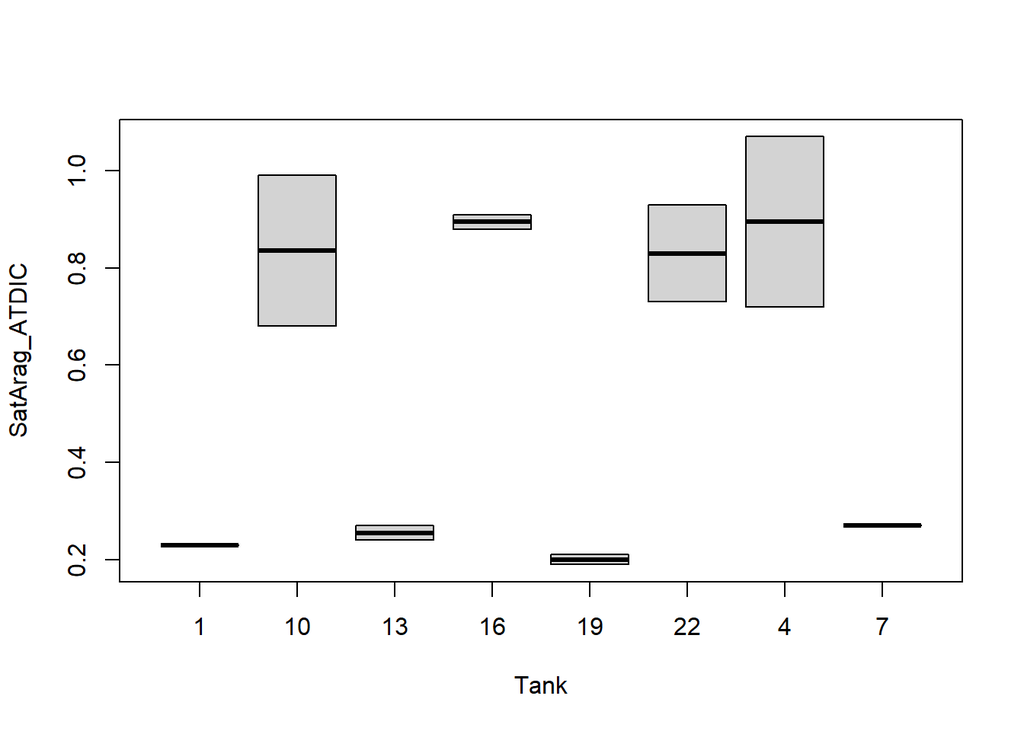

```r
#subset the tank data to only include B1 and only those that are to be used for water chemistry.
Tank_WCB1<- subset(Tank_WC, UseForCalcite == "TRUE")
Tank_WCB1$Tank<-droplevels(Tank_WCB1)$Tank #drop unused levels
Tank_WCB1$ParentTrt<- droplevels(Tank_WCB1)$ParentTrt
#test to see if tanks are significantly different (they should not be)
boxplot(SatArag_ATDIC~Tank, data=Tank_WCB1, na.omit=TRUE)
```

```r
#check for significant differences in saturation state between tanks within treatments
Ca1<- lmer(SatArag_ATDIC~ParentTrt + (1|Tank), data=Tank_WCB1)
```

```
## boundary (singular) fit: see ?isSingular
```

```r
Ca2<- lmer(SatArag_ATDIC~ 1 + (1|Tank), data= Tank_WCB1)
anova(Ca1, Ca2) #select Ca1
```

```
## refitting model(s) with ML (instead of REML)
```

```
## Data: Tank_WCB1
## Models:
## Ca2: SatArag_ATDIC ~ 1 + (1 | Tank)
## Ca1: SatArag_ATDIC ~ ParentTrt + (1 | Tank)
##     npar      AIC      BIC  logLik deviance  Chisq Df Pr(>Chisq)
## Ca2    3   5.4768   7.7945  0.2616  -0.5232
## Ca1    4 -21.9764 -18.8860 14.9882 -29.9764 29.453  1  5.729e-08 ***
## ---
## Signif. codes:  0 '***' 0.001 '**' 0.01 '*' 0.05 '.' 0.1 ' ' 1
```

```r
Ca3<- lm(SatArag_ATDIC~ParentTrt, data=Tank_WCB1)
anova(Ca1, Ca3) #select Ca3
```

```
## refitting model(s) with ML (instead of REML)
```

```
## Data: Tank_WCB1
## Models:
## Ca3: SatArag_ATDIC ~ ParentTrt
## Ca1: SatArag_ATDIC ~ ParentTrt + (1 | Tank)
##     npar     AIC     BIC logLik deviance Chisq Df Pr(>Chisq)
## Ca3    3 -23.976 -21.659 14.988  -29.976
## Ca1    4 -21.976 -18.886 14.988  -29.976     0  1          1
```

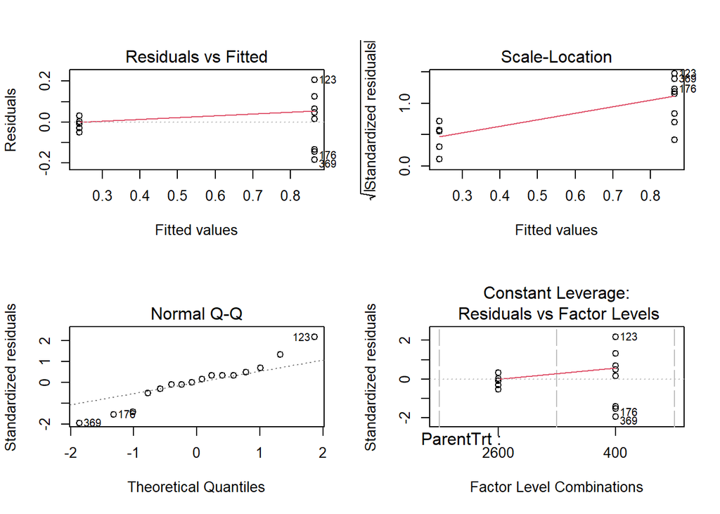

```r
#check assumptions
par(mfcol=c(2,2))
plot(Ca3) #seems to meet assumptions of homoscedasticity and linearity.
```

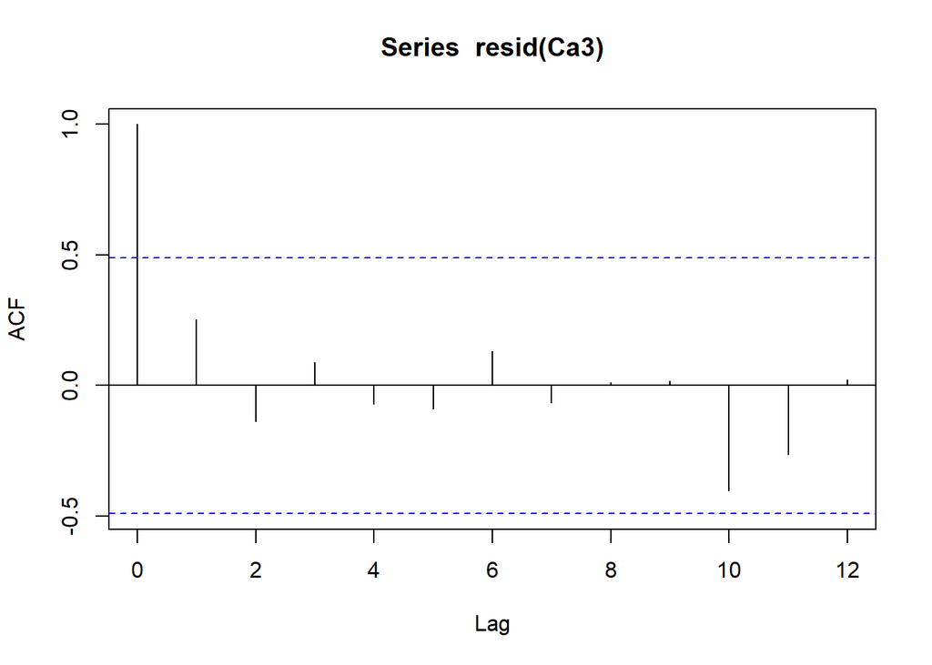

```r
par(mfcol=c(1,1))
acf(resid(Ca3)) #this looks good.
```

```r
summary(Ca3) #There is a significant effect of ParentTrt, but not tank according to best model.
```

```
##
## Call:
## lm(formula = SatArag_ATDIC ~ ParentTrt, data = Tank_WCB1)
##
## Residuals:
##      Min       1Q   Median       3Q      Max
## -0.18375 -0.03375  0.00875  0.03500  0.20625
##
## Coefficients:
##              Estimate Std. Error t value Pr(>|t|)
## (Intercept)   0.23875    0.03584   6.661 1.08e-05 ***
## ParentTrt400  0.62500    0.05069  12.331 6.59e-09 ***
## ---
## Signif. codes:  0 '***' 0.001 '**' 0.01 '*' 0.05 '.' 0.1 ' ' 1
##
## Residual standard error: 0.1014 on 14 degrees of freedom
## Multiple R-squared:  0.9157, Adjusted R-squared:  0.9097
## F-statistic:   152 on 1 and 14 DF,  p-value: 6.594e-09
```

## Get Tank Means

```r
#create data frame that has the mean values for each tank
TankMeans<- ddply(Tank_WCB1, .(Tank, Block, ParentTrt), numcolwise(mean, na.rm=T))
TankSes<- ddply(Tank_WCB1, .(Tank, Block, ParentTrt), numcolwise(se, na.rm=T))
```

## Carbonate Chemistry Summary Table for Tanks

Compile all of the data for the summary table.

```r
Tank_WCB1sum<- subset(Tank_WCB1, select=c("ParentTrt", "pHTotal", "salinity", "temperature", "DIC_corr", "Alk_corr", "AT_Calc_SW", "pCO2_ATDIC", "HCO3_ATDIC", "CO3_ATDIC", "CO2_ATDIC", "SatCalcite_ATDIC", "SatArag_ATDIC"))
colnames(Tank_WCB1sum)<- paste(c("Trt", "pH", "Sal", "Temp", "DIC", "ATmeas","ATcalc", "pCO2", "HCO3", "CO3", "CO2", "Calcite", "Aragonite"))
CarbChemTanks<- CarbChemSummary(DF=Tank_WCB1sum)
write.csv(CarbChemTanks,"~/R/GitHub/LarvaeTransGen2018/data/TankCarbChemSummary.csv")
```

# Join the data into dataframe for Egg analysis

```r
#First data frame will be for examining egg morphology for all eggs traced; multiple values for each adult
AdultSampParID<- merge(x=Adult_Sample, y=Parent_ID, by="AdultID", all.x=TRUE)
AdultSampParID<- merge(x=AdultSampParID, y=TankMeans, by.x="TrtTankID", by.y="Tank", all.x=TRUE)
AdultSampParID<- subset(AdultSampParID, ParentBlockID !="NA")
AdultSampParID<- subset(AdultSampParID, Block =="B1")
MaleInfo<- subset(AdultSampParID, Sex=="M")
FemaleInfo<- subset(AdultSampParID, Sex=="F")
colnames(MaleInfo)<- paste("Male", colnames(MaleInfo), sep="")
Eggs<- merge(x=Egg_Morphology, y=FemaleInfo, by.x="FemaleID", by.y="ParentBlockID", all.x=TRUE)
Eggs$FemaleID<- as.factor(Eggs$FemaleID)
#subset the data to only include B1
EggsB1<- subset(Eggs, Block =="B1")
```

Visualize the data for eggs to start

```r
#get the original range of the eggs
range(EggsB1$EggDiamum)
```

```
## [1] 15.35819 92.72958
```

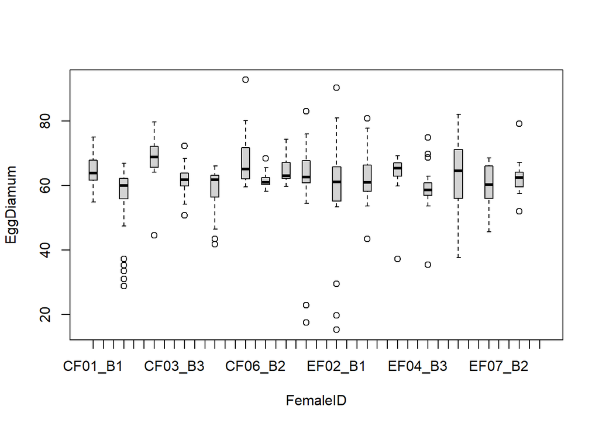

```r
#look at the egg measurements to see outliers
boxplot(EggDiamum~FemaleID, data=EggsB1)
```

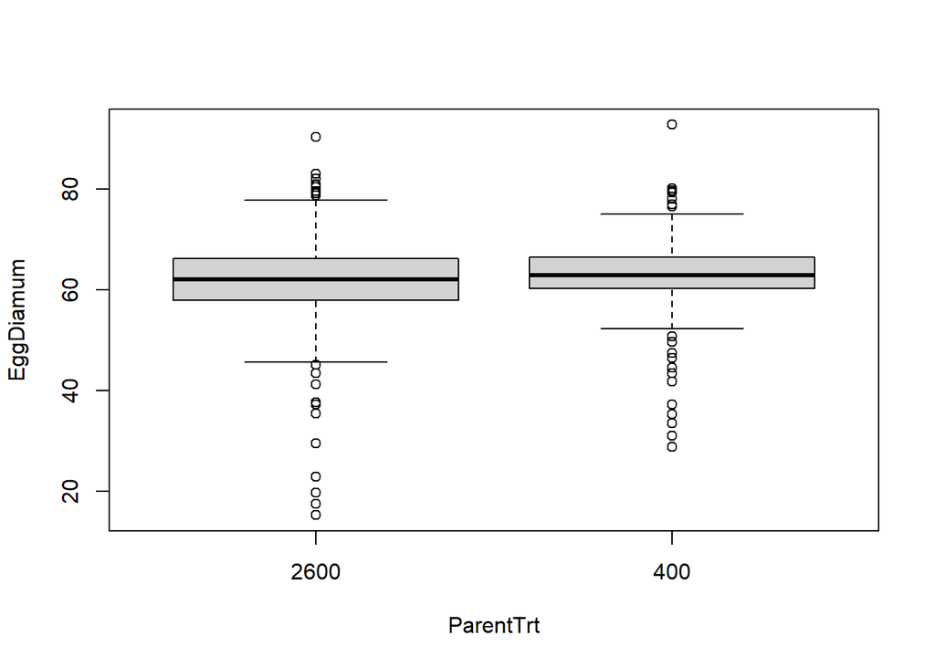

```r
boxplot(EggDiamum~ParentTrt, data=EggsB1)
```

## Test for significant effect of parent treatment on egg size before removing outliers.

```r
CalEggs<- EggsB1

eggdiam1AllEggs<- lmer(EggDiamum~ParentTrt*AdultLength + (1|FemaleID)  + (1|AccTankID), data=CalEggs)
```

```
## boundary (singular) fit: see ?isSingular
```

```r
eggstepAllEggs<-step(eggdiam1AllEggs)
print(eggstepAllEggs)
```

```
## Backward reduced random-effect table:
##
##                 Eliminated npar  logLik    AIC    LRT Df Pr(>Chisq)
## <none>                        7 -1649.1 3312.1
## (1 | AccTankID)          1    6 -1649.1 3310.1  0.000  1          1
## (1 | FemaleID)           0    5 -1664.6 3339.2 31.055  1  2.508e-08 ***
## ---
## Signif. codes:  0 '***' 0.001 '**' 0.01 '*' 0.05 '.' 0.1 ' ' 1
##
## Backward reduced fixed-effect table:
## Degrees of freedom method: Satterthwaite
##
##                       Eliminated Sum Sq Mean Sq NumDF  DenDF F value Pr(>F)
## ParentTrt:AdultLength          1  0.063   0.063     1 12.019  0.0009 0.9763
## AdultLength                    2 35.012  35.012     1 13.038  0.5088 0.4882
## ParentTrt                      3 45.959  45.959     1 14.281  0.6678 0.4272
##
## Model found:
## EggDiamum ~ (1 | FemaleID)
```

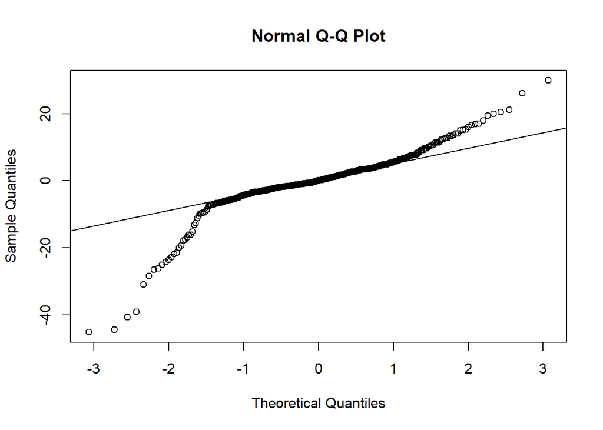

```r
#final model chosen: EggDiamum~ 1 + (1|FemaleID)
eggdiamfinAllEggs<- lmer(EggDiamum~1+(1|FemaleID), data=CalEggs)
#Check assumptions
par(mfcol=c(1,1))
qqnorm(resid(eggdiamfinAllEggs))
qqline(resid(eggdiamfinAllEggs))
```

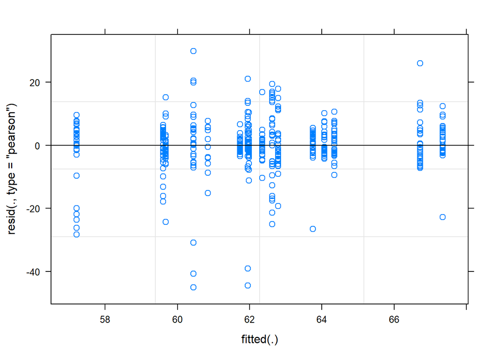

```r
plot(eggdiamfinAllEggs)
```

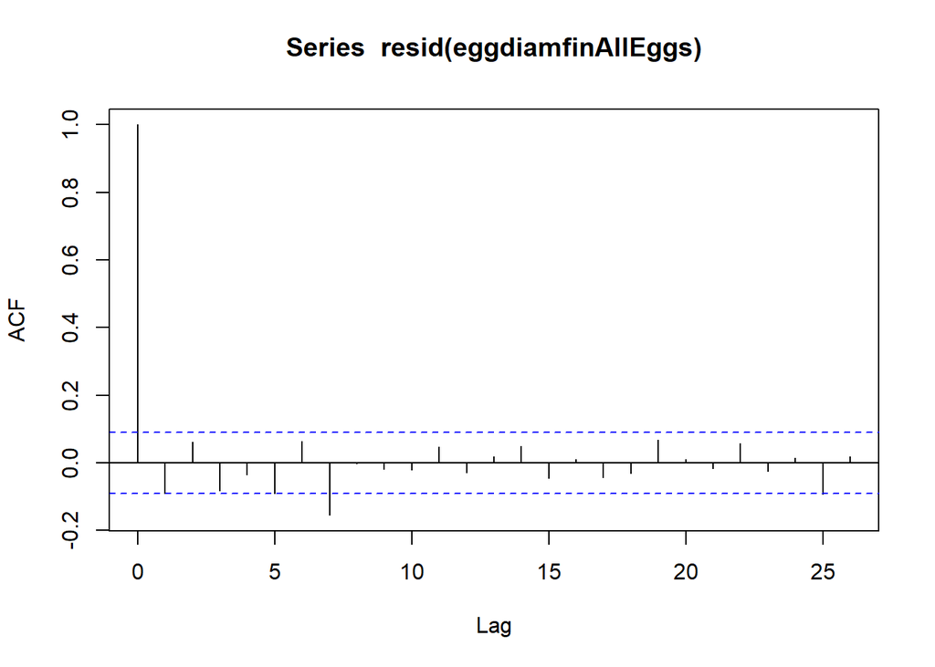

```r
acf(resid(eggdiamfinAllEggs))
```

```r
summary(eggdiamfinAllEggs)
```

```
## Linear mixed model fit by REML. t-tests use Satterthwaite's method [
## lmerModLmerTest]
## Formula: EggDiamum ~ 1 + (1 | FemaleID)
##    Data: CalEggs
##
## REML criterion at convergence: 3309.2
##
## Scaled residuals:
##     Min      1Q  Median      3Q     Max
## -5.4348 -0.3241  0.0129  0.4322  3.6031
##
## Random effects:
##  Groups   Name        Variance Std.Dev.
##  FemaleID (Intercept)  8.64    2.939
##  Residual             68.82    8.296
## Number of obs: 465, groups:  FemaleID, 16
##
## Fixed effects:
##             Estimate Std. Error      df t value Pr(>|t|)
## (Intercept)  62.3403     0.8329 15.2019   74.85   <2e-16 ***
## ---
## Signif. codes:  0 '***' 0.001 '**' 0.01 '*' 0.05 '.' 0.1 ' ' 1
```

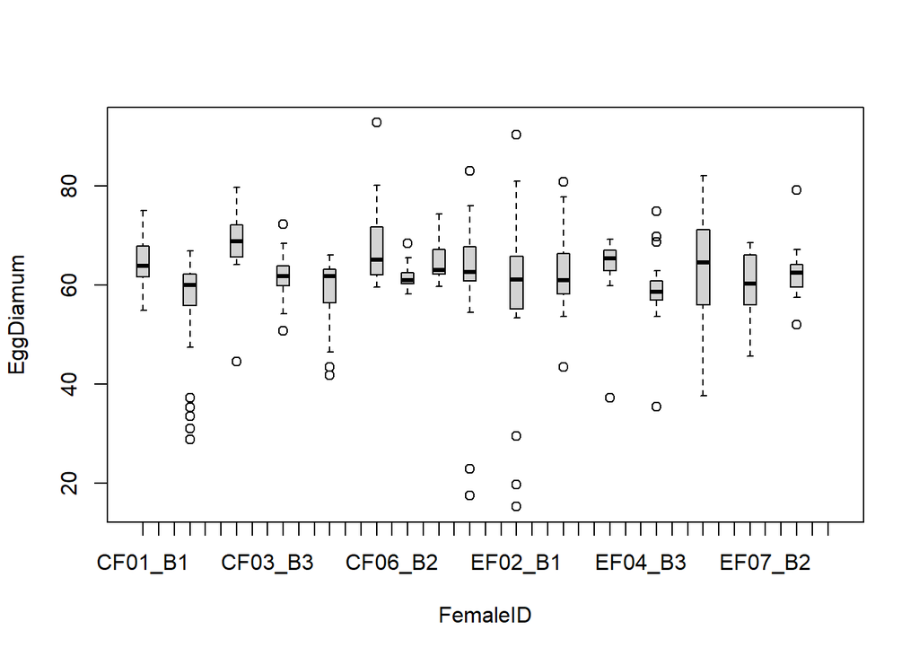

```r
#Conclusion: Female matters but not treatment or adult length. Acclimation tank and treatment tank also don't matter.
plot(EggDiamum~FemaleID, data=CalEggs) #we need to account for FemaleID, but not egg size in Larvae models.
```

```r
#test shape of eggs using eccentricity
eggeccenAllEggs<- lmer(EggEccentricity~ParentTrt*AdultLength + (1|FemaleID) + (1|AccTankID), data=CalEggs)
```

```
## boundary (singular) fit: see ?isSingular
```

```r
eccenstepAllEggs<- step(eggeccenAllEggs)
print(eccenstepAllEggs)
```

```
## Backward reduced random-effect table:
##
##                 Eliminated npar logLik     AIC    LRT Df Pr(>Chisq)
## <none>                        7 219.79 -425.58
## (1 | AccTankID)          1    6 219.79 -427.58  0.000  1          1
## (1 | FemaleID)           0    5 198.69 -387.39 42.192  1  8.275e-11 ***
## ---
## Signif. codes:  0 '***' 0.001 '**' 0.01 '*' 0.05 '.' 0.1 ' ' 1
##
## Backward reduced fixed-effect table:
## Degrees of freedom method: Satterthwaite
##
##                       Eliminated    Sum Sq   Mean Sq NumDF  DenDF F value
## ParentTrt:AdultLength          1 0.0036001 0.0036001     1 11.984  0.1747
## AdultLength                    2 0.0018589 0.0018589     1 13.000  0.0902
## ParentTrt                      3 0.0177255 0.0177255     1 14.237  0.8601
##                       Pr(>F)
## ParentTrt:AdultLength 0.6834
## AdultLength           0.7687
## ParentTrt             0.3692
##
## Model found:
## EggEccentricity ~ (1 | FemaleID)
```

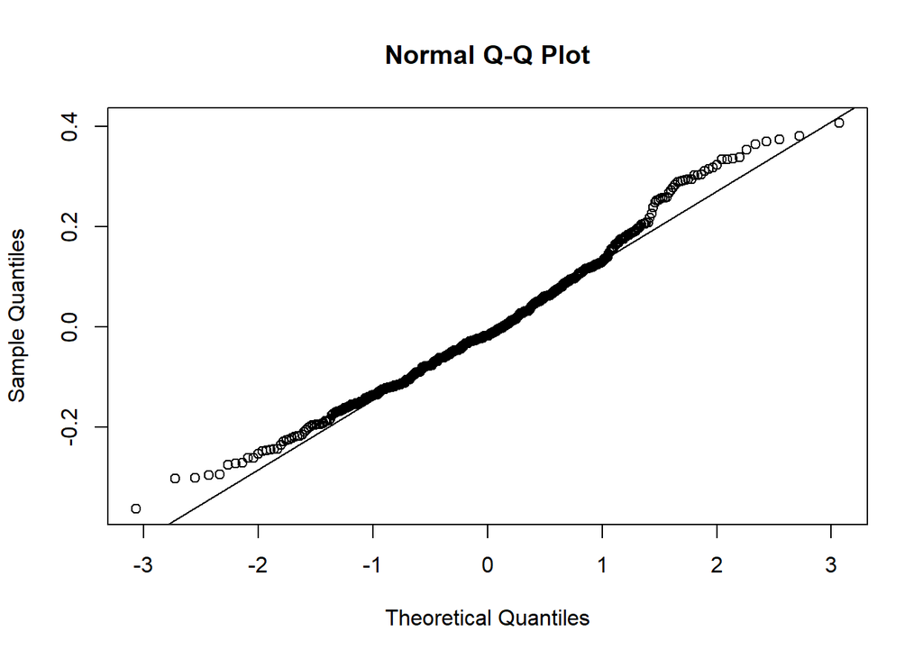

```r
eggeccenfinAllEggs<- lmer(EggEccentricity~(1|FemaleID), data=CalEggs)
qqnorm(resid(eggeccenfinAllEggs))
qqline(resid(eggeccenfinAllEggs))
```

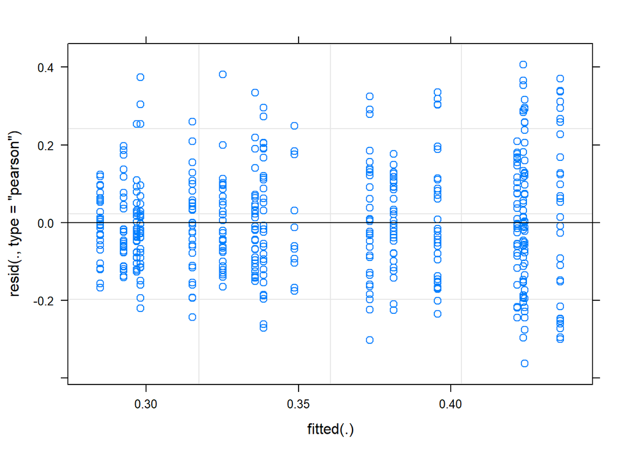

```r
plot(eggeccenfinAllEggs)
```

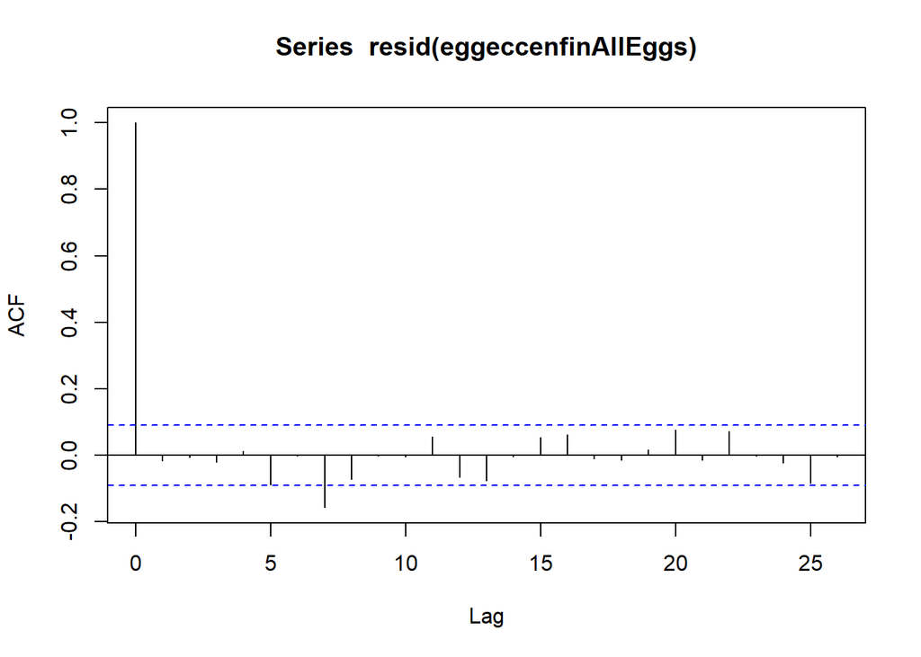

```r
acf(resid(eggeccenfinAllEggs))
```

```r
summary(eggeccenfinAllEggs)
```

```
## Linear mixed model fit by REML. t-tests use Satterthwaite's method [
## lmerModLmerTest]
## Formula: EggEccentricity ~ (1 | FemaleID)
##    Data: CalEggs
##
## REML criterion at convergence: -452.3
##
## Scaled residuals:
##     Min      1Q  Median      3Q     Max
## -2.5291 -0.6995 -0.1186  0.6072  2.8342
##
## Random effects:
##  Groups   Name        Variance Std.Dev.
##  FemaleID (Intercept) 0.003396 0.05827
##  Residual             0.020607 0.14355
## Number of obs: 465, groups:  FemaleID, 16
##
## Fixed effects:
##             Estimate Std. Error       df t value Pr(>|t|)
## (Intercept)  0.35575    0.01608 15.28143   22.13 5.03e-13 ***
## ---
## Signif. codes:  0 '***' 0.001 '**' 0.01 '*' 0.05 '.' 0.1 ' ' 1
```

Remove egg outliers

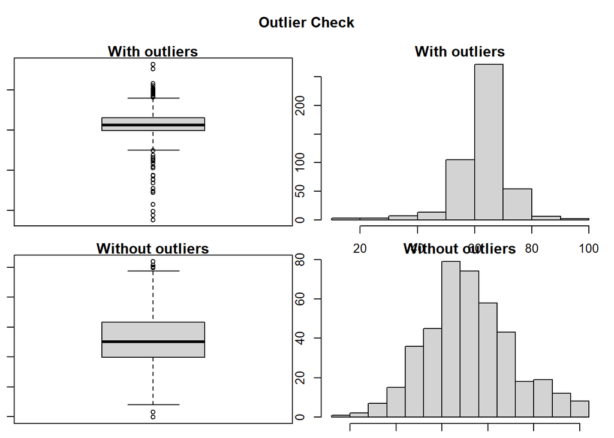

```
## Outliers identified: 48 nPropotion (%) of outliers: 11.5 nMean of the outliers: 57.63 nMean without removing outliers: 62.4 nMean if we remove outliers: 62.95 nOutliers successfully removed n
```

```r
par(mar=c(1,1,1,1))
#check for outliers using code from https://www.r-bloggers.com/identify-describe-plot-and-remove-the-outliers-from-the-dataset/. The function uses Tukey's method to ID outliers ranged above and below the 1.5*IQR.
outlierKD <- function(dt, var) {
     var_name <- eval(substitute(var),eval(dt))
     na1 <- sum(is.na(var_name))
     m1 <- mean(var_name, na.rm = T)
     par(mfrow=c(2, 2), oma=c(0,0,3,0))
     boxplot(var_name, main="With outliers")
     hist(var_name, main="With outliers", xlab=NA, ylab=NA)
     outlier <- boxplot.stats(var_name)$out
     mo <- mean(outlier)
     var_name <- ifelse(var_name %in% outlier, NA, var_name)
     boxplot(var_name, main="Without outliers")
     hist(var_name, main="Without outliers", xlab=NA, ylab=NA)
     title("Outlier Check", outer=TRUE)
     na2 <- sum(is.na(var_name))
     cat("Outliers identified:", na2 - na1, "n")
     cat("Propotion (%) of outliers:", round((na2 - na1) / sum(!is.na(var_name))*100, 1), "n")
     cat("Mean of the outliers:", round(mo, 2), "n")
     m2 <- mean(var_name, na.rm = T)
     cat("Mean without removing outliers:", round(m1, 2), "n")
     cat("Mean if we remove outliers:", round(m2, 2), "n")
    dt[as.character(substitute(var))] <- invisible(var_name)
    assign(as.character(as.list(match.call())$dt), dt, envir = .GlobalEnv)
    cat("Outliers successfully removed", "n")
    return(invisible(dt))
}
outlierKD(EggsB1, EggDiamum)
```

```r
#Outliers identified: 48 nPropotion (%) of outliers: 11.5 nMean of the outliers: 57.63 nMean without removing outliers: 62.4 nMean if we remove outliers: 62.95 n
#count how many eggs are left per female after removing the outliers.
outrem<- aggregate(EggDiamum~FemaleID, data=EggsB1, FUN=length)
#EF07_B1 had 10 eggs that were included the rest were removed. Keep EF07_B1 in the analysis
#remove eggs that have NAs for EggDiamum
EggsB1<- subset(EggsB1, EggDiamum != "NA")
EggsB1$EggPerimeterum<- EggsB1$EggPerimeterPix/8.892  #add a column to convert egg perimeter to um based on the scaled slide
EggsB1$EggPerimDiamRat<- EggsB1$EggPerimeterum/EggsB1$EggDiamum #add a column for the ratio of perimeter to diameter
```

Visualize eggs without outliers

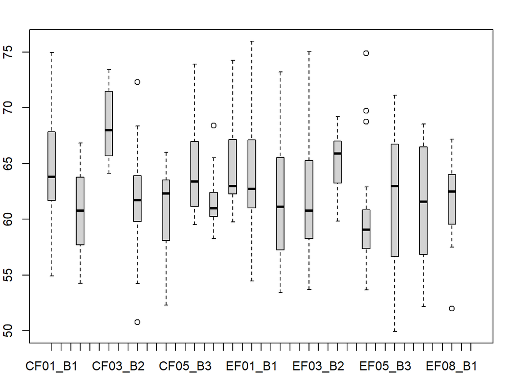

```r
#Plot again without outliers
par(mfcol=c(1,1), mar=c(2,2,2,2))
boxplot(EggDiamum~FemaleID, data=EggsB1)
```

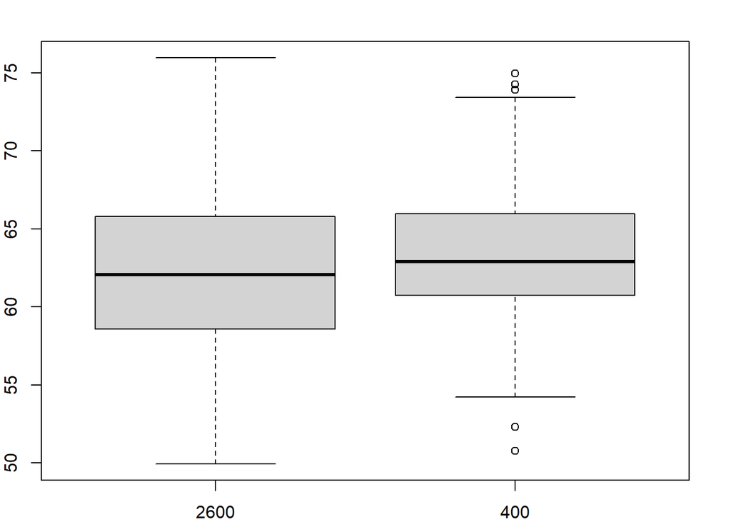

```r
boxplot(EggDiamum~ParentTrt, data=EggsB1)
```

```r
#get the range without outliers
range(EggsB1$EggDiamum, na.rm=TRUE)
```

```
## [1] 49.95329 75.96955
```

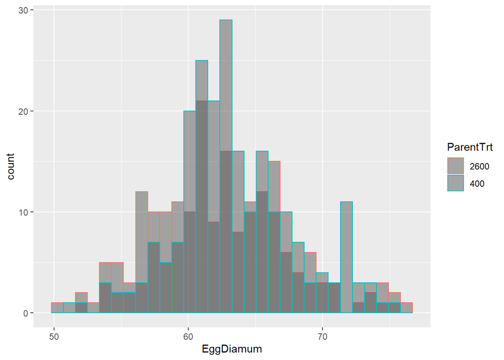

```r
#note that the eggs were filtered through a 70 um filter, but it appears that larger ones made it through.
#plot histograms of the egg data with outliers removed
ggplot(EggsB1, aes(x=EggDiamum, color=ParentTrt))+
  geom_histogram(alpha=0.5, position="identity")
```

```r
eggmeans<- aggregate(EggDiamum~ParentTrt, data=EggsB1, FUN=mean) #400 = 63.45709; 2800= 62.36829
eggmedians<- aggregate(EggDiamum~ParentTrt, data=EggsB1, FUN=median)#400 = 62.91200; 2800= 62.06727
#I will use the mean egg size.
```

## Make datasets without the egg size outliers

```r
meanegg<- ddply(EggsB1, .(FemaleID), numcolwise(mean, na.rm=T)) #get mean egg size
#select only columns that we need for egg morph
meanegg<- subset(meanegg, select=c("FemaleID", "EggDiamum"))
FemAdults<- merge(x=FemaleInfo, y= meanegg, by.x="ParentBlockID", by.y= "FemaleID", all.y=TRUE, all.x=TRUE)
#Next dataframe will be for one line per traced larva, includes all the data for that jar, including average egg size for that jar
Larvae<-merge(x=Larvae_Morphology, y=Barcode_Jar, by="JarID", all.x=TRUE) %>% merge(y=Larvae_WC, by="JarID", all.x=TRUE, all.y=TRUE)
#use gather function in tidyr to make the Fert_QG Jar ID columns in long form vs. wide form
Fert_QG_long <- Fert_QG %>% tidyr::gather(Key, JarID, JarID1:JarID6)
#use the gathered data frame to merge with Larvae
Larvae<-merge(x=Larvae, y=Fert_QG_long, by.x= c("JarID", "CrossID"), by.y=c("JarID", "CrossID"), all.x=TRUE) %>% merge(y=Cross, by="CrossID", all.x=TRUE) %>%  merge(y=FemAdults, by.x= "FemaleID", by.y="ParentBlockID", all.x=TRUE) %>% merge(y=MaleInfo, by.x= "MaleID", by.y="MaleParentBlockID", all.x=TRUE) %>% merge(y= Larvae_Counts, by="JarID", all.x=TRUE)
#Remove jars without larvae
Larvae<- subset(Larvae, Larvae=="TRUE")
#Get a fixed date and time column
str(Larvae$DateFixed)
```

```
##  int [1:3758] 20180727 20180727 20180727 20180727 20180727 20180727 20180727 20180727 20180727 20180727 ...
```

```r
Larvae$FixedDateFormatted<- as.Date(as.character(Larvae$DateFixed),format="%Y%m%d")
Larvae$FixedDateTime<- as.POSIXct(paste(Larvae$FixedDateFormatted, Larvae$TimeFixed), format="%Y-%m-%d %H:%M")

#get the growth per day for the larva
Larvae$GrowthPerDay<- (Larvae$LarvaeDiamum*(mean(eggmeans$EggDiamum)/Larvae$EggDiamum))/3
#Final data frame will be one line per Jar, includes all data for the jar, including the average larva size per jar and cilia

LarvByJar<- merge(x=Larvae_Calcification, y=Barcode_Jar, by="JarID", all.x=TRUE) %>%  merge(y=Larvae_WC, by="JarID", all.x=TRUE)%>% merge(y=Fert_QG_long, by.x=c("JarID", "CrossID"), by.y=c("JarID","CrossID"), all.x=TRUE) %>% merge(y=Cross, by="CrossID", all.x=TRUE) %>%
merge(y=FemAdults, by.x="FemaleID", by.y="ParentBlockID", all.x=TRUE) %>% merge(y=MaleInfo, by.x="MaleID", by.y="MaleParentBlockID", all.x=TRUE) %>% merge(y=Larvae_Counts, by="JarID", all.x=TRUE)

#get the means for larvae morphology and add to LarvByJar
MeanLarvMorph<- ddply(Larvae_Morphology, .(JarID), numcolwise(mean, na.rm=T))
SELarvMorph<- ddply(Larvae_Morphology, .(JarID), numcolwise(se, na.rm=T)) #get standard error of larva size
MeanLarvMorph<- full_join(MeanLarvMorph,SELarvMorph, by="JarID", suffix=c("", "SE")) #join the mean and se larvae data
LarvByJar<- merge(x=LarvByJar, y=MeanLarvMorph, by="JarID", all.x=TRUE)
LarvByJar$MeanGPD<- (LarvByJar$LarvaeDiamum*(mean(eggmeans$EggDiamum)/LarvByJar$EggDiamum))/3

#Now let's add the survival data. See notes on "Larvae Survival" for more info on how we decided to count total larvae in the jar
#Make columns for the two larvae counts for 1_5 and 2
LarvByJar$v1_5SurvCount<- rowSums(LarvByJar[,c("SWRTotal", "F2LarvaeCount")], na.rm=TRUE)
LarvByJar$v2SurvCount<- rowSums(LarvByJar[,c("F1LarvaeCount", "F2LarvaeCount")], na.rm=TRUE)
#use ifelse statement to define the LarvaeSurvived column
LarvByJar$LarvaeSurvived<- ifelse(LarvByJar$ProtocolVersion =="1", paste(LarvByJar$TotalLarvae), ifelse(LarvByJar$ProtocolVersion =="1_5", paste(LarvByJar$v1_5SurvCount), paste(LarvByJar$v2SurvCount)))
LarvByJar$LarvaeSurvived<- as.numeric(LarvByJar$LarvaeSurvived)
#get the total larvae for the control jars and exposed jars for each family and then get the ratio of exposed to control to get an idea of how good a male and female pair are at larvae surviving. Can also use this to create reaction norms.
SurvDat<- ddply(LarvByJar, .(CrossID, ParentTrt, JarTrt, MaleID, FemaleID, TrtTankID,MaleTrtTankID, AccTankID, Block), numcolwise(mean, na.rm=TRUE))
SESurvDat<- ddply(LarvByJar, .(CrossID, ParentTrt, JarTrt, Block), numcolwise(se, na.rm=TRUE)) #get the standard errors for each mean count
SESurvDat<- subset(SESurvDat, select= c(CrossID, JarTrt, LarvaeSurvived, SatArag_ATDIC, JarSatArg_Total, MeanGPD)) #select only certain columns.
colnames(SESurvDat)<- paste("SE", colnames(SESurvDat), sep="")
#merge the standard error data to the SurvDat dataframe
SurvDat<- merge(SurvDat, SESurvDat, by.x= c("CrossID", "JarTrt"), by.y= c("SECrossID", "SEJarTrt"))
#only keep the relevant fields because otherwise this is a huge data frame
SurvDat<- subset(SurvDat, select= c(CrossID, JarTrt, ParentTrt, MaleID, FemaleID, TrtTankID,MaleTrtTankID, AccTankID, LarvaeSurvived, Block, SELarvaeSurvived, SatArag_ATDIC, MeanGPD, SEMeanGPD))
SurvDat<- subset(SurvDat, Block=="B1" & CrossID !="")
#use the spread function to go from long form to wide form for the survival data

SurvDatToWide<- unite(SurvDat, Value, c(LarvaeSurvived, SELarvaeSurvived, MeanGPD, SEMeanGPD), sep="_")
SurvWideDat<- spread(SurvDatToWide, JarTrt, value= Value)
#now split the mean and SE apart again
SurvWideDat<- separate(SurvWideDat, Control, into= c("MeanLarvSurvivedCon", "SELarvSurvivedCon", "MeanGPDCon", "SEMeanGPDCon"), sep="_")
SurvWideDat<- separate(SurvWideDat, Exposed, into= c("MeanLarvSurvivedExp", "SELarvSurvivedExp", "MeanGPDExp", "SEMeanGPDCExp"), sep="_")
#make the means and ses numeric
SurvWideDat$MeanLarvSurvivedExp<- as.numeric(SurvWideDat$MeanLarvSurvivedExp)
SurvWideDat$MeanLarvSurvivedCon<- as.numeric(SurvWideDat$MeanLarvSurvivedCon)
SurvWideDat$SELarvSurvivedExp<- as.numeric(SurvWideDat$SELarvSurvivedExp)
SurvWideDat$SELarvSurvivedCon<- as.numeric(SurvWideDat$SELarvSurvivedCon)
SurvWideDat$MeanGPDCon<- as.numeric(SurvWideDat$MeanGPDCon)
SurvWideDat$MeanGPDExp<- as.numeric(SurvWideDat$MeanGPDExp)
SurvWideDat$SEMeanGPDCon<- as.numeric(SurvWideDat$SEMeanGPDCon)
SurvWideDat$SEMeanGPDCExp<- as.numeric(SurvWideDat$SEMeanGPDCExp)
SurvWideDat$RatSurv<- SurvWideDat$MeanLarvSurvivedExp/SurvWideDat$MeanLarvSurvivedCon
SurvWideDat$RatGPD<- SurvWideDat$MeanGPDExp/SurvWideDat$MeanGPDCon
SurvWideDat$SurvChange<- (SurvWideDat$MeanLarvSurvivedCon-SurvWideDat$MeanLarvSurvivedExp)/SurvWideDat$MeanLarvSurvivedCon
SurvWideDat$CrossID<- as.factor(SurvWideDat$CrossID)
SurvWideDat$FemaleID<- as.factor(SurvWideDat$FemaleID)
SurvWideDat$MaleID<- as.factor(SurvWideDat$MaleID)
LarvByJar<- subset(LarvByJar, Larvae=="TRUE")

#now remove the data we do not want to analyze.
LarvaeDat<- subset(Larvae, Block == "B1")
#get a column without B1 in the female and male IDs
LarvaeDat$FemIDPlain<- vapply(strsplit(as.character(LarvaeDat$FemaleID),"_"), `[`, 1, FUN.VALUE=character(1))
LarvaeDat$MaleIDPlain<- vapply(strsplit(as.character(LarvaeDat$MaleID),"_"), `[`, 1, FUN.VALUE=character(1))
#now make things factors and drop levels
LarvaeDat$JarID<- as.factor(LarvaeDat$JarID)
LarvaeDat$JarID<-droplevels(LarvaeDat)$JarID
LarvaeDat$AccTankID<- as.factor(LarvaeDat$AccTankID)
LarvaeDat$AccTankID<-droplevels(LarvaeDat)$AccTankID
LarvaeDat$TrtTankID<- as.factor(LarvaeDat$TrtTankID)
LarvaeDat$TrtTankID<-droplevels(LarvaeDat)$TrtTankID
LarvaeDat$MaleTrtTankID<- as.factor(LarvaeDat$MaleTrtTankID)
LarvaeDat$MaleTrtTankID<-droplevels(LarvaeDat)$MaleTrtTankID
LarvaeDat$MaleAccTankID<- as.factor(LarvaeDat$MaleAccTankID)
LarvaeDat$MaleAccTankID<-droplevels(LarvaeDat)$MaleAccTankID
LarvaeDat$JarSeatable<- as.factor(LarvaeDat$JarSeatable)

LarvaeDat$JarSeatable<-droplevels(LarvaeDat)$JarSeatable
LarvaeDat$JarTrt<- as.factor(LarvaeDat$JarTrt)
LarvaeDat$ParentTrt<- as.factor(LarvaeDat$ParentTrt)
LarvaeDat$FemaleID<- as.factor(LarvaeDat$FemaleID)
LarvaeDat$FemaleID<-droplevels(LarvaeDat)$FemaleID
LarvaeDat$MaleID<- as.factor(LarvaeDat$MaleID)
LarvaeDat$MaleID<-droplevels(LarvaeDat)$MaleID
LarvaeDat$CrossID<- as.factor(LarvaeDat$CrossID)
LarvaeDat$CrossID<-droplevels(LarvaeDat)$CrossID

LarvByJarDat<- subset(LarvByJar, Block == "B1" & JarSatArg_Total !="NA")
LarvByJarDat$JarID<- as.factor(LarvByJarDat$JarID)
LarvByJarDat$AccTankID<- as.factor(LarvByJarDat$AccTankID)
LarvByJarDat$TrtTankID<- as.factor(LarvByJarDat$TrtTankID)
LarvByJarDat$MaleAccTankID<- as.factor(LarvByJarDat$MaleAccTankID)
LarvByJarDat$MaleTrtTankID<- as.factor(LarvByJarDat$MaleTrtTankID)
LarvByJarDat$JarSeatable<- as.factor(LarvByJarDat$JarSeatable)
LarvByJarDat$ParentTrt<- as.factor(LarvByJarDat$ParentTrt)
LarvByJarDat$FemaleID<- as.factor(LarvByJarDat$FemaleID)
LarvByJarDat$MaleID<- as.factor(LarvByJarDat$MaleID)
LarvByJarDat$CrossID<- as.factor(LarvByJarDat$CrossID)
LarvByJarDat$JarTrt<- as.factor(LarvByJarDat$JarTrt)
LarvByJarDat$MaleID<-droplevels(LarvByJarDat)$MaleID
LarvByJarDat$FemaleID<-droplevels(LarvByJarDat)$FemaleID
LarvByJarDat$CrossID<-droplevels(LarvByJarDat)$CrossID
LarvByJarDat$FemIDPlain<- vapply(strsplit(as.character(LarvByJarDat$FemaleID),"_"), `[`, 1, FUN.VALUE=character(1))
LarvByJarDat$MaleIDPlain<- vapply(strsplit(as.character(LarvByJarDat$MaleID),"_"), `[`, 1, FUN.VALUE=character(1))
LarvByJarDat$MaleIDNumber<- substr(LarvByJarDat$MaleIDPlain, 3, 4 )
LarvByJarDat$FemaleIDNumber<- substr(LarvByJarDat$FemIDPlain, 3, 4 )

LarvaeDat$PerimLenRat<-LarvaeDat$LarvaePerimeterum/LarvaeDat$LarvaeDiamum
```

## Analyze jar chemistry data

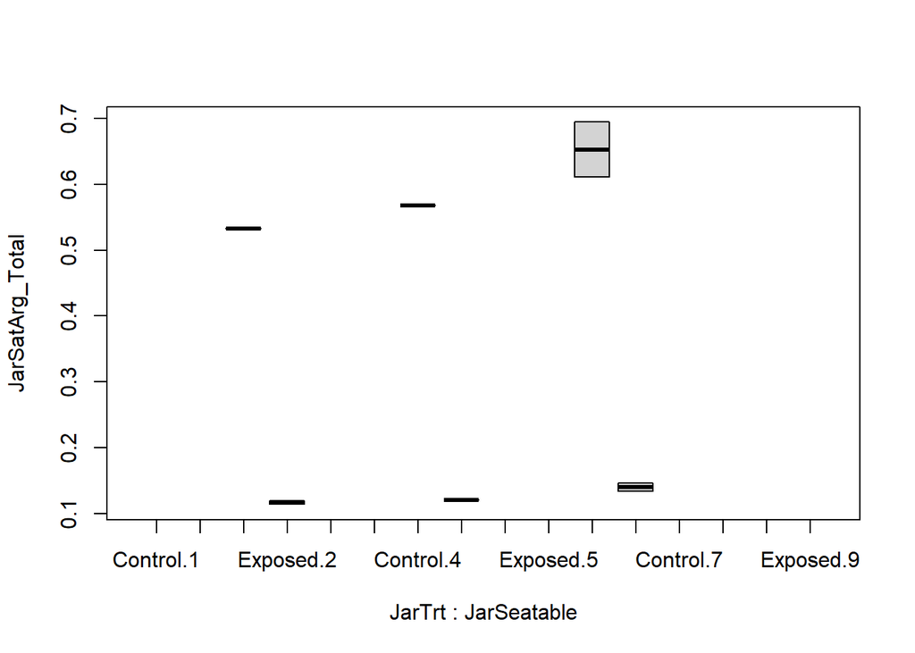

```r
CalJar<- subset(LarvByJarDat, BottleChemistry=="TRUE" )#only use those that had their chem measured
#look at the saturation state for jars
boxplot(JarSatArg_Total~JarTrt*JarSeatable, data=CalJar)
```

```r
Jar2<- lmer(JarSatArg_Total~JarTrt + (1|JarSeatable), data=CalJar)
Jar2step<- step(Jar2)
```

```
## Error in as_lmerModLmerTest(model): model not of class 'lmerMod': cannot coerce to class 'lmerModLmerTest
```

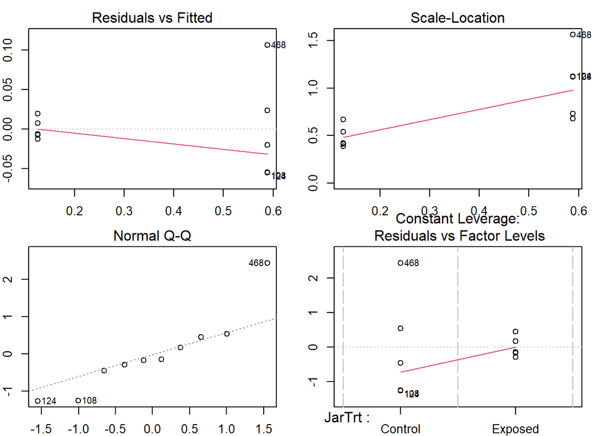

```r
#get error model not of class lmerMod. I looked up this issue and turns out that error results when all random effects are dropped. See https://stackoverflow.com/questions/55638476/how-to-do-stepwise-model-with-random-effect-lme4-lmertest for more info if you want.
JarFin<- lm(JarSatArg_Total~JarTrt, data=CalJar)
#check assumptions
par(mfcol=c(2,2), mar=c(2,2,2,2))
plot(JarFin)
```

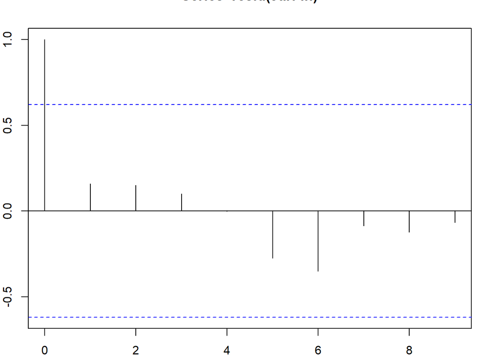

```r
par(mfcol=c(1,1))
acf(resid(JarFin))
```

```r
summary(JarFin)
```

```
##
## Call:
## lm(formula = JarSatArg_Total ~ JarTrt, data = CalJar)
##
## Residuals:
##       Min        1Q    Median        3Q       Max
## -0.055314 -0.018150 -0.007068  0.016544  0.106529
##
## Coefficients:
##               Estimate Std. Error t value Pr(>|t|)
## (Intercept)    0.58806    0.02182   26.95 3.87e-09 ***
## JarTrtExposed -0.46149    0.03086  -14.95 3.95e-07 ***
## ---
## Signif. codes:  0 '***' 0.001 '**' 0.01 '*' 0.05 '.' 0.1 ' ' 1
##
## Residual standard error: 0.0488 on 8 degrees of freedom
## Multiple R-squared:  0.9655, Adjusted R-squared:  0.9611
## F-statistic: 223.6 on 1 and 8 DF,  p-value: 3.95e-07
```

```r
#Conclusion: JarSeatable not significant.
```